# Coursera Satistical Inference - Course Project PART 2

Author: Dino Chioda Date: May 23, 2015

# Overview

In this project, which is the second part of the Course Project for the Statistical Inference course, we’re going to analyze the ToothGrowth data in the R datasets package. We will provide a basic summary of the data ans use confidence intervals to test hypotheses for tooth growth by supplement and dose.

## Question 1: Load the ToothGrowth data and perform some basic exploratory data analyses

```r
# Load the data
library(datasets)
data(ToothGrowth)

# Look at the data
nrow(ToothGrowth)
```

```
## [1] 60
```

```r
str(ToothGrowth)
```

```
## 'data.frame':    60 obs. of  3 variables:
##  $ len : num  4.2 11.5 7.3 5.8 6.4 10 11.2 11.2 5.2 7 ...
##  $ supp: Factor w/ 2 levels "OJ","VC": 2 2 2 2 2 2 2 2 2 2 ...
##  $ dose: num  0.5 0.5 0.5 0.5 0.5 0.5 0.5 0.5 0.5 0.5 ...
```

```r
ToothGrowth$dose <- as.factor(ToothGrowth$dose)
str(ToothGrowth)
```

```
## 'data.frame':    60 obs. of  3 variables:
##  $ len : num  4.2 11.5 7.3 5.8 6.4 10 11.2 11.2 5.2 7 ...
##  $ supp: Factor w/ 2 levels "OJ","VC": 2 2 2 2 2 2 2 2 2 2 ...
##  $ dose: Factor w/ 3 levels "0.5","1","2": 1 1 1 1 1 1 1 1 1 1 ...
```

## Question 2: Provide a baisc summary of the data

```r
summary(ToothGrowth)
```

```
##       len        supp     dose
##  Min.   : 4.20   OJ:30   0.5:20
##  1st Qu.:13.07   VC:30   1  :20
##  Median :19.25           2  :20
##  Mean   :18.81
##  3rd Qu.:25.27
##  Max.   :33.90
```

Let’s generate some basic box plots to gain a better understand of how the data behaves:

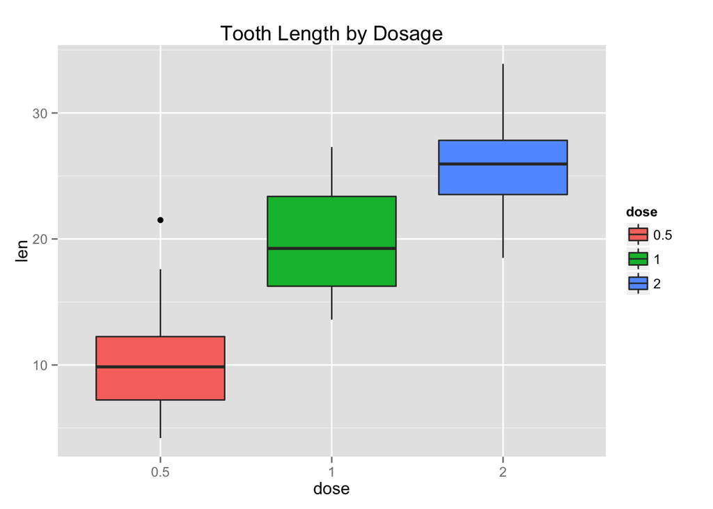

```r
library(ggplot2)
len_dose <- ggplot(aes(x=dose, y=len), data=ToothGrowth) + geom_boxplot(aes(fill=dose)) +
        ggtitle("Tooth Length by Dosage")
print(len_dose)
```

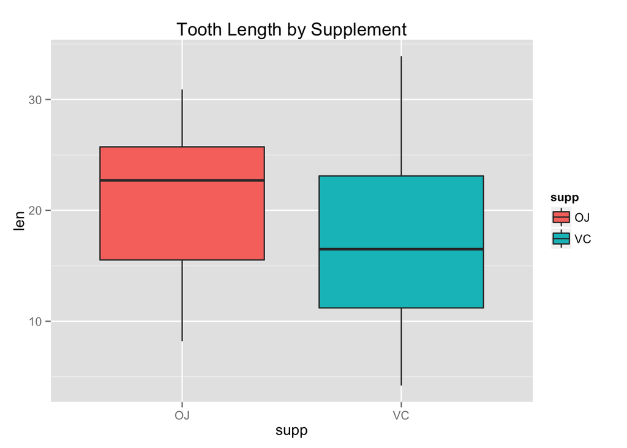

```r
ggplot(aes(x=supp, y=len), data=ToothGrowth) + geom_boxplot(aes(fill=supp)) +
        ggtitle("Tooth Length by Supplement")
```

## Question 3: Use confidence intervals and hypothesis tests to compare tooth growth by supp and dose.

Consider the following hypothesis:

$H_0$: Supplements have no effect on tooth length

$H_A$: Supplements have an effect on tooth length

We will use a t-test to assess that the $H_0$ is true.

```r
t.test(len~supp, ToothGrowth)
```

```
##
##  Welch Two Sample t-test
##
## data:  len by supp
## t = 1.9153, df = 55.309, p-value = 0.06063
## alternative hypothesis: true difference in means is not equal to 0
## 95 percent confidence interval:
##  -0.1710156  7.5710156
## sample estimates:
## mean in group OJ mean in group VC
##         20.66333         16.96333
```

The p-value of the t-test is **0.06**. Therefore, we cannot reject the null hypothesis.

Consider the following hypothesis:

$H_0$: Increasing the dosage has no effect on tooth length

$H_A$: Increasing the dosage has an effect on tooth length

Since we have 3 distinct dosages, we have 3 possible dosage pairs to consider. Therefore, we will perform a t-test on each of the dosage pairings. Let’s begin by subsetting by dosage pairings: 0.5 & 1.0, 0.5 & 2.0, 1.0 & 2.0:

```r
ToothGrowth.doses_0.5_1.0 <- subset (ToothGrowth, dose %in% c(0.5, 1.0))
ToothGrowth.doses_0.5_2.0 <- subset (ToothGrowth, dose %in% c(0.5, 2.0))
ToothGrowth.doses_1.0_2.0 <- subset (ToothGrowth, dose %in% c(1.0, 2.0))
```

Let’s perform the t-tests to validate $H_0$:

```r
t.test(len ~ dose, data = ToothGrowth.doses_0.5_1.0)
```

```
##
##  Welch Two Sample t-test
##
## data:  len by dose
## t = -6.4766, df = 37.986, p-value = 1.268e-07
## alternative hypothesis: true difference in means is not equal to 0
## 95 percent confidence interval:
##  -11.983781  -6.276219
## sample estimates:
## mean in group 0.5   mean in group 1
##            10.605            19.735
```

```r
t.test(len ~ dose, data = ToothGrowth.doses_0.5_2.0)
```

```
##
##  Welch Two Sample t-test
##
## data:  len by dose
## t = -11.799, df = 36.883, p-value = 4.398e-14
## alternative hypothesis: true difference in means is not equal to 0
## 95 percent confidence interval:
##  -18.15617 -12.83383
## sample estimates:
## mean in group 0.5   mean in group 2
##            10.605            26.100
```

```r
t.test(len ~ dose, data = ToothGrowth.doses_1.0_2.0)
```

```
##
##  Welch Two Sample t-test
##
## data:  len by dose
## t = -4.9005, df = 37.101, p-value = 1.906e-05
## alternative hypothesis: true difference in means is not equal to 0
## 95 percent confidence interval:
##  -8.996481 -3.733519
## sample estimates:
## mean in group 1 mean in group 2
##          19.735          26.100
```

Since all 3 p-values are less than 0.05 and the confidence intervals do not contain 0, we can reject $H_0$ and state that increasing the dosage leads to increased tooth length.

## Question 4: State you conclusions and the assumptions needed for your conclusions.

### Conclusions

1. Supplement type does not seem to have an effect on tooth length.
2. Increasing dosage levels does appear to lead to increased tooth length.